# Exercise 15.3

Lucia Camenisch

22 January 2023

First of all, we upload the necessary packages.

```r
library(data.table)   # data table, fread
library(ggplot2)      # plotting
library(knitr)        # r markdown
library(kableExtra)   # kable parameters
library(dplyr)        # %>% function
library(tidyr)        # gather
library(e1071)        # skewness()
library(caret)        # preProcess() for scaling data
library(usedist)      # adding/changing dist labels with dist_setNames()

options(scipen = 999) # avoid scientific notation
```

We load our data, examine its structure using `str`, get a first idea of the variables distributions using `summary` and print a table of the number of unique values each variable takes.

```r
cereals <- fread("cereals.csv")                       # import data
str(cereals)                                          # data structure
```

```
## Classes 'data.table' and 'data.frame':   77 obs. of  16 variables:
##  $ name    : chr  "100%_Bran" "100%_Natural_Bran" "All-Bran" "All-Bran_with_Extra_Fiber" ...
##  $ mfr     : chr  "N" "Q" "K" "K" ...
##  $ type    : chr  "C" "C" "C" "C" ...
##  $ calories: int  70 120 70 50 110 110 110 130 90 90 ...
##  $ protein : int  4 3 4 4 2 2 2 3 2 3 ...
##  $ fat     : int  1 5 1 0 2 2 0 2 1 0 ...
##  $ sodium  : int  130 15 260 140 200 180 125 210 200 210 ...
##  $ fiber   : num  10 2 9 14 1 1.5 1 2 4 5 ...
##  $ carbo   : num  5 8 7 8 14 10.5 11 18 15 13 ...
##  $ sugars  : int  6 8 5 0 8 10 14 8 6 5 ...
##  $ potass  : int  280 135 320 330 NA 70 30 100 125 190 ...
##  $ vitamins: int  25 0 25 25 25 25 25 25 25 25 ...
##  $ shelf   : int  3 3 3 3 3 1 2 3 1 3 ...
##  $ weight  : num  1 1 1 1 1 1 1 1.33 1 1 ...
##  $ cups    : num  0.33 1 0.33 0.5 0.75 0.75 1 0.75 0.67 0.67 ...
##  $ rating  : num  68.4 34 59.4 93.7 34.4 ...
##  - attr(*, ".internal.selfref")=<externalptr>
```

```r
summary(cereals)                                      # data summary
```

```
##      name               mfr                type              calories
##  Length:77          Length:77          Length:77          Min.   : 50.0
##  Class :character   Class :character   Class :character   1st Qu.:100.0
##  Mode  :character   Mode  :character   Mode  :character   Median :110.0
##                                                           Mean   :106.9
##                                                           3rd Qu.:110.0
##                                                           Max.   :160.0
##
##     protein           fat            sodium          fiber
##  Min.   :1.000   Min.   :0.000   Min.   :  0.0   Min.   : 0.000
##  1st Qu.:2.000   1st Qu.:0.000   1st Qu.:130.0   1st Qu.: 1.000
##  Median :3.000   Median :1.000   Median :180.0   Median : 2.000
##  Mean   :2.545   Mean   :1.013   Mean   :159.7   Mean   : 2.152
##  3rd Qu.:3.000   3rd Qu.:2.000   3rd Qu.:210.0   3rd Qu.: 3.000
##  Max.   :6.000   Max.   :5.000   Max.   :320.0   Max.   :14.000
##
##      carbo          sugars           potass          vitamins
##  Min.   : 5.0   Min.   : 0.000   Min.   : 15.00   Min.   :  0.00
##  1st Qu.:12.0   1st Qu.: 3.000   1st Qu.: 42.50   1st Qu.: 25.00
##  Median :14.5   Median : 7.000   Median : 90.00   Median : 25.00
##  Mean   :14.8   Mean   : 7.026   Mean   : 98.67   Mean   : 28.25
##  3rd Qu.:17.0   3rd Qu.:11.000   3rd Qu.:120.00   3rd Qu.: 25.00
##  Max.   :23.0   Max.   :15.000   Max.   :330.00   Max.   :100.00
##  NA's   :1      NA's   :1        NA's   :2
##      shelf           weight          cups           rating
##  Min.   :1.000   Min.   :0.50   Min.   :0.250   Min.   :18.04
##  1st Qu.:1.000   1st Qu.:1.00   1st Qu.:0.670   1st Qu.:33.17
##  Median :2.000   Median :1.00   Median :0.750   Median :40.40
##  Mean   :2.208   Mean   :1.03   Mean   :0.821   Mean   :42.67
##  3rd Qu.:3.000   3rd Qu.:1.00   3rd Qu.:1.000   3rd Qu.:50.83
##  Max.   :3.000   Max.   :1.50   Max.   :1.500   Max.   :93.70
##
```

```r
t(t(sapply(cereals, function(x) length(unique(x)))))  # number of unique values
```

```
##          [,1]
## name       77
## mfr         7
## type        2
## calories   11
## protein     6
## fat         5
## sodium     27
## fiber      13
## carbo      22
## sugars     17
## potass     36
## vitamins    3
## shelf       3
## weight      7
## cups       12
## rating     77
```

As we saw in exercise 4.1, `name`, `mfr`, `type` and `shelf` are all categorical variables. The book states that if we are dealing with a mix of categorical and numerical variables, we should use *Gower’s similarity measure*. However, this exercise asks us to use the *Euclidean distance*. As the Euclidean distance has no meaning on categorical variables, we cannot include them with the numerical ones. Thus, we choose to discard the categorical variables for this exercise, with the exception of `name`, which has no explanatory power but serves as a row identifier.

```r
# deleting categorical variables
cereals <- cereals[, -c(2,3,13)]
```

Remember that in exercise 4.1, we had already identified missing values inside our data. We display the missing values here again.

```r
# printing rows and columns which contain NA values
kable_styling(kable(cereals[rowSums(is.na(cereals)) > 0,list(name, carbo, sugars, potass)]),
              full_width = FALSE)
```

| name | carbo | sugars | potass |
| --- | --- | --- | --- |
| Almond_Delight | 14 | 8 | NA |
| Cream_of_Wheat_(Quick) | 21 | 0 | NA |
| Quaker_Oatmeal | NA | NA | 110 |

Per the exercise’s instructions, we will delete the rows with missing values.

```r
# function na.omit() removes rows which contain missing values
cereals <- na.omit(cereals)
# we keep a copy of the variables with their original values, as we will start transforming below
cereals.raw <- cereals
```

Let us plot the distributions of all our variables.

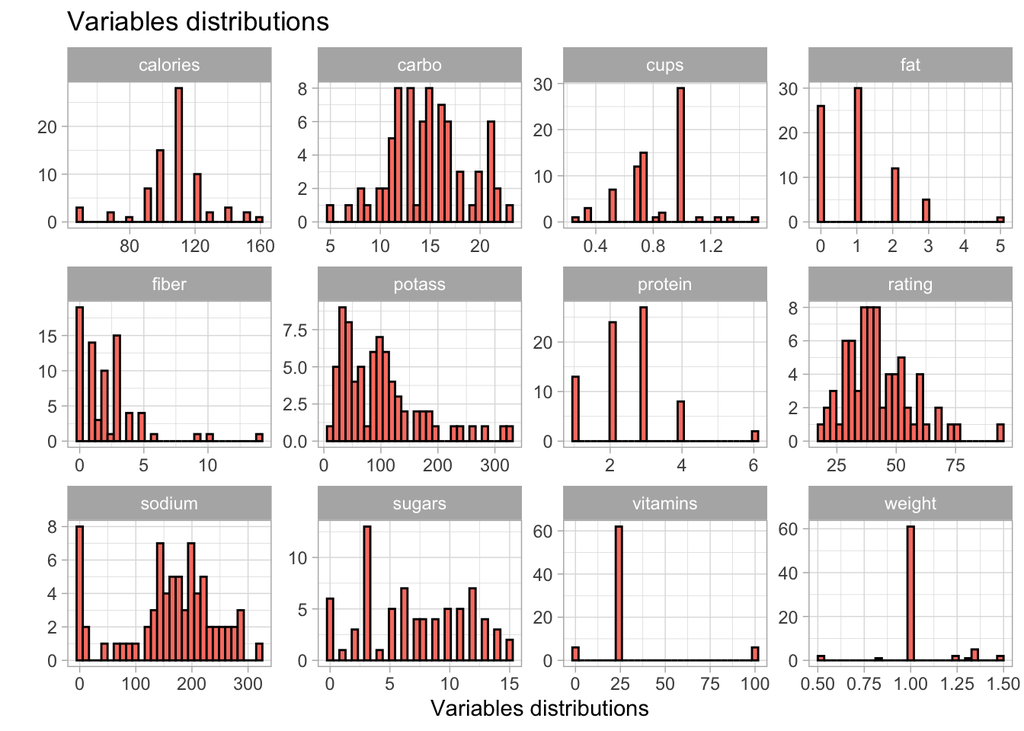

```r
cereals[, -c(1)] %>% gather() %>%                        # gather transforms data into two columns with
                                                      # "key" and "value"
  ggplot(aes(value)) +                                # plotting the value
  facet_wrap(~ key, scales = "free") +                # making one plot for each key with facet
  geom_histogram(color = "black", fill = "#FA8072") + # making histograms
  theme_light() +                                     # aesthetic theme for our plots
  labs(x = "Variables distributions", y = "",         # label of the figure
       title = "Variables distributions")
```

We look at the skewness index for our variables.

```r
# sapply() allows to use skewness() on multiple columns of our data
sapply(cereals[, -c(1)], skewness)
```

```
##    calories     protein         fat      sodium       fiber       carbo
## -0.44215253  0.71443137  1.19164666 -0.58706561  2.28774328  0.11358083
##      sugars      potass    vitamins      weight        cups      rating
##  0.04535843  1.34252764  2.42837680  0.26962634 -0.11036392  0.92418242
```

We can see that:

- `fat`, `fiber`, `potass` and `vitamins` are highly skewed.
- `protein`, `sodium` and `rating` are moderately skewed.

We will use logarithm transformations on `fat`, `fiber`, `potass` and `rating`, and square root transformations on `vitamins`, `protein` and `sodium`.

```r
sapply(cereals[, c(4,6,9,10)], skewness)    # skewness of highly skewed vars
```

```
##      fat    fiber   potass vitamins
## 1.191647 2.287743 1.342528 2.428377
```

```r
cereals$fat <- log(cereals$fat + 1)         # log transform with + 1 as min value is 0
cereals$fiber <- log(cereals$fiber + 1)     # log transform with + 1 as min value is 0
cereals$potass <- log(cereals$potass)       # log transform
cereals$vitamins <- sqrt(cereals$vitamins)  # sqrt transform

sapply(cereals[, c(4,6,9,10)], skewness)    # skewness once vars are transformed
```

```
##         fat       fiber      potass    vitamins
##  0.14287720  0.11951665 -0.07526159  0.00000000
```

```r
sapply(cereals[, c(3,5,13)], skewness)      # skewness of moderately skewed vars
```

```
##    protein     sodium     rating
##  0.7144314 -0.5870656  0.9241824
```

```r
cereals$protein <- sqrt(cereals$protein)    # sqrt transform
cereals$sodium <- sqrt(max(cereals$sodium)  # sodium is negatively skewed so we have to transform
                       - cereals$sodium)    # by sqrt(maxvalue - x)
cereals$rating <- log(cereals$rating)       # log transform

sapply(cereals[, c(3,5,13)], skewness)      # skewness once vars are transformed
```

```
##     protein      sodium      rating
##  0.05334722 -0.37414244 -0.04214362
```

Now, the skewness indexes are all under 0.5 in absolute value! We plot our variables distributions again.

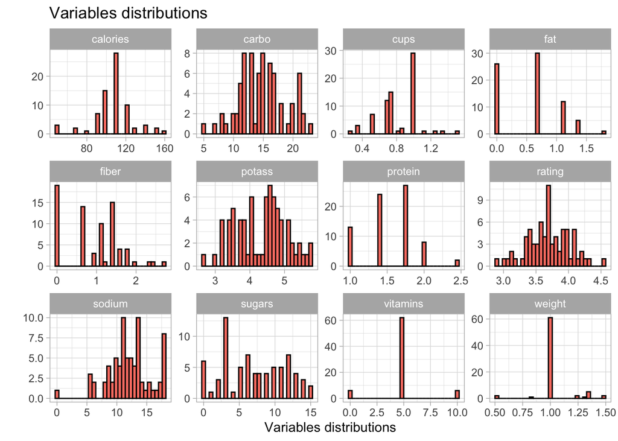

```r
cereals[, -c(1)] %>% gather() %>%                        # gather transforms data into two columns with
                                                      # "key" and "value"
  ggplot(aes(value)) +                                # plotting the value
  facet_wrap(~ key, scales = "free") +                # making one plot for each key with facet
  geom_histogram(color = "black", fill = "#FA8072") + # making histograms
  theme_light() +                                     # aesthetic theme for our plots
  labs(x = "Variables distributions", y = "",         # label of the figure
       title = "Variables distributions")
```

We can now normalize our data, using `preProcess` from the `caret` package.

```r
# computing mean and sd of each variable
norm.values <- preProcess(cereals[, -c(1)], method=c("center", "scale"))

# normalizing using predict
cereals <- predict(norm.values, cereals)
```

# 1 Apply hierarchical clustering to the data using Euclidean distance to the normalized measurements.

We first compute the Euclidean distance matrix of record.

As we are working with data tables instead of data frames, naming rows will not work like with data frames. Instead, we use the function `dist_setNames` from package `usedist` to change the labels in the distance matrix so they reflect the brand name of cereals.

```r
# computing distance matrix with dist, specifying euclidean as method
EuclDist <- dist(cereals[, -c(1)], method = "euclidean")
# changing labels of distance matrix
EuclDist <- dist_setNames(EuclDist, cereals$name)
```

We start by clustering using single linkage.

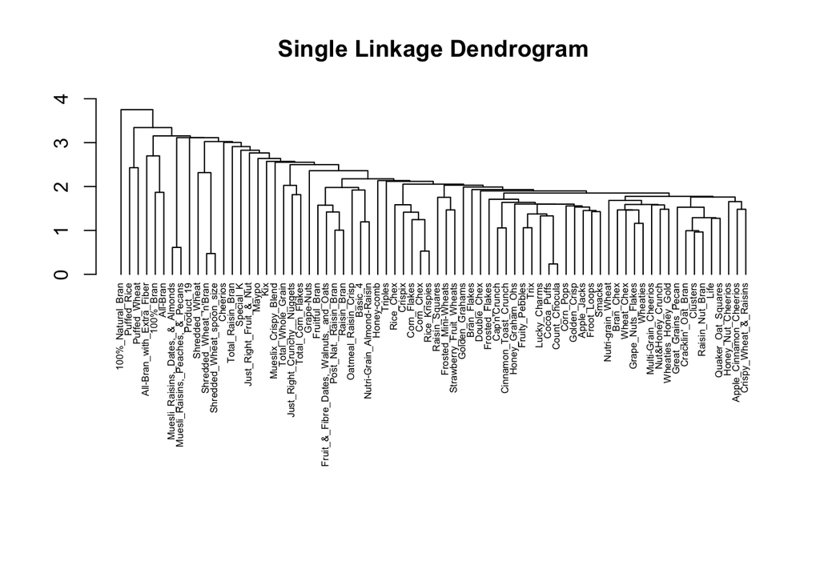

```r
# clustering with single linkage
ClustSingle <- hclust(EuclDist, method = "single")
# plotting the dendrogram
plot(ClustSingle,
     hang = -1,                           # names are all aligned at the same height
     cex = 0.5,                           # size of text labels
     xlab = "", ylab = "", sub = "",      # labels of plot
     main = "Single Linkage Dendrogram")  # title of plot
```

Now, we cluster using complete linkage.

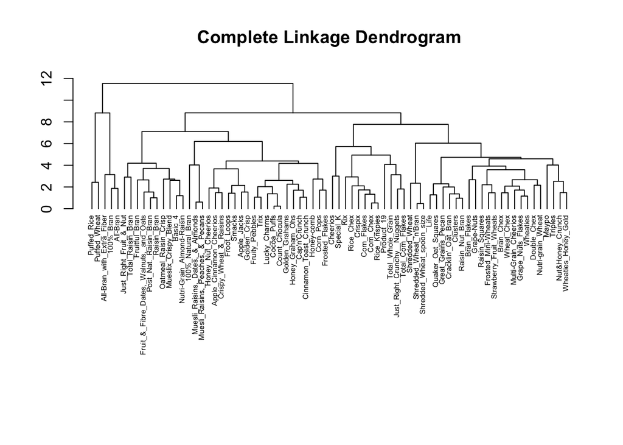

```r
# clustering with complete linkage
ClustComplete <- hclust(EuclDist, method = "complete")
# plotting the dendrogram
plot(ClustComplete,
     hang = -1,                             # names are all aligned at the same height
     cex = 0.5,                             # size of text labels
     xlab = "", ylab = "", sub = "",        # labels of plot
     main = "Complete Linkage Dendrogram")  # title of plot
```

We need to decide at which height to cut our dendrograms. This will determine the number of clusters we have for our data.

In order to do so, we plot the heights of each split in our dendrograms by ascending order.

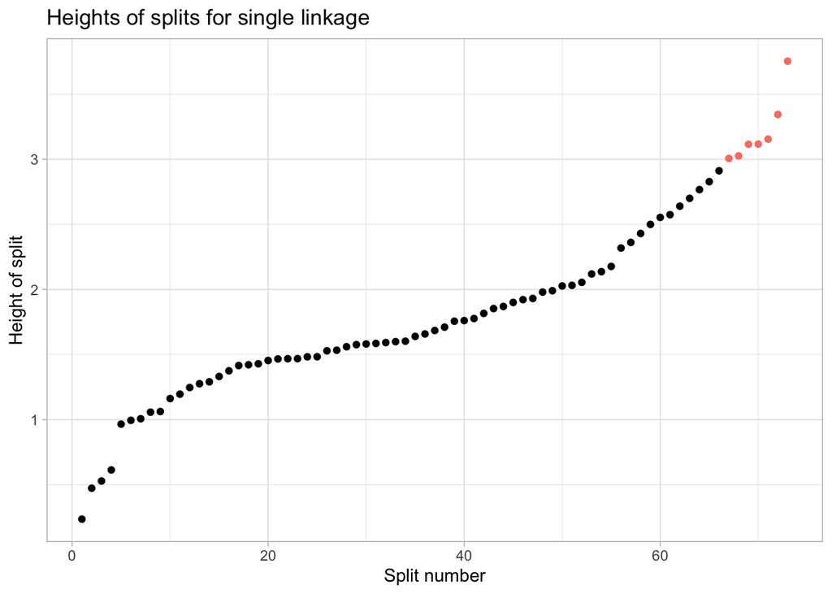

```r
# we create a data table which indexes splits and gives their corresp height in both clusterings
Heights <- data.table(Index = 1:length(ClustSingle$height),  # index number of split
                      SingleHeight = ClustSingle$height,     # split heights in single linkage
                      CompleteHeight = ClustComplete$height) # split heights in complete linkage

# plotting split heights for both clusters
# we color the splits which we will use to determine clusters
ggplot(data = Heights[1:66,], aes(x = Index, y = SingleHeight)) +   # plotting black dots
  geom_point() +
  geom_point(data = Heights[67:73,], color = "#FA8072") +           # plotting pink dots
  theme_light() +
  labs(x = "Split number", y = "Height of split",
       title = "Heights of splits for single linkage")
```

[figure not shown]

```r
ggplot(data = Heights[1:65,], aes(x = Index, y = CompleteHeight)) +
  geom_point() +
  geom_point(data = Heights[66:73,], color = "#FA8072") +
  theme_light() +
  labs(x = "Split number", y = "Height of split",
       title = "Heights of splits for single linkage")
```

For single linkage, we decide to use the first seven splits (shown in pink), which will then result into eight different clusters.

For complete linkage, we will use the first eight splits (shown in pink), so we’ll have nine clusters.

The intuition was to try and cut on splits before we get to a line of points with equidistant splits in our plots, which seem more grouped. This was easier to identify and decide on complete linkage than on single linkage.

We now cut our dendrograms and display the histograms of how cereals are distributed into clusters.

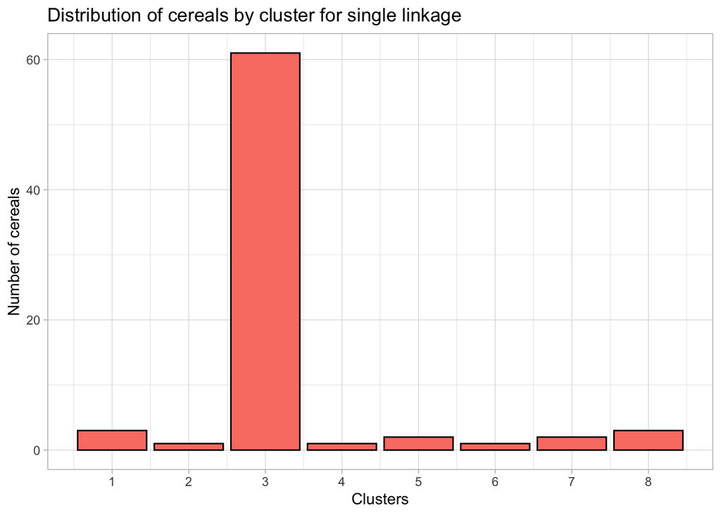

```r
# Cutting single linkage to 8 clusters
CutSingle <- cutree(ClustSingle, k = 8)
# Cutting complete linkage to 8 clusters
CutComplete <- cutree(ClustComplete, k = 9)

# plotting distributions of cereals in clusters
ggplot(data = as.data.table(CutSingle), aes(x = CutSingle)) +           # plotting CutSingle
  geom_bar(color = "black", fill = "#FA8072") +                         # colors of geom_bar
  scale_x_continuous(breaks = 1:8) +                                    # scale of x
  theme_light() +
  labs(x = "Clusters", y = "Number of cereals",
       title = "Distribution of cereals by cluster for single linkage")
```

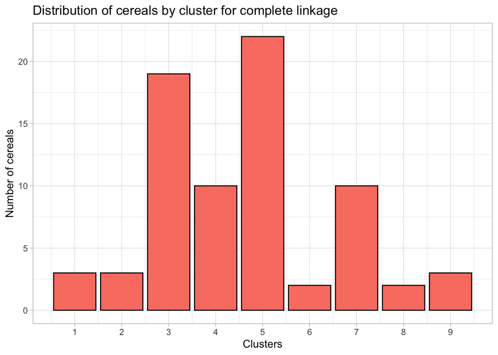

```r
# same plot but for CutComplete
ggplot(data = as.data.table(CutComplete), aes(x = CutComplete)) +
  geom_bar(color = "black", fill = "#FA8072") +
  scale_x_continuous(breaks = 1:9) +
  theme_light() +
  labs(x = "Clusters", y = "Number of cereals",
       title = "Distribution of cereals by cluster for complete linkage")
```

We can see that single linkage produces one big cluster which contains the vast majority of our cereal brands. Complete linkage is more balanced in comparison.

We now compute the centroids of each cluster for single and complete linkage.

```r
# we first add two cluster columns to cereals and cereals.row which indicate the cluster
cereals[, ClustSingle := CutSingle]
cereals[, ClustComplete := CutComplete]

cereals.raw[, ClustSingle := CutSingle]
cereals.raw[, ClustComplete := CutComplete]

# we compute the mean values of each variable by aggregating on the cluster number
# we do so for normalized data and raw data
# for normalize data:
CentSingleNorm <- aggregate(cereals[, -c(1,14,15)],            # aggregating variables
                            by = list(cereals$ClustSingle),    # by the cluster numbers
                            FUN = mean)                        # computing the mean
CentCompleteNorm <- aggregate(cereals[, -c(1,14,15)],
                             by = list(cereals$ClustComplete),
                             FUN = mean)
# for raw data:
CentSingle <- aggregate(cereals.raw[, -c(1,14,15)],
                        by = list(cereals.raw$ClustSingle),
                        FUN = mean)
CentComplete <- aggregate(cereals.raw[, -c(1,14,15)],
                         by = list(cereals.raw$ClustComplete),
                         FUN = mean)
```

We now plot our results. When we give the results by cluster, it is better to use normalized data, as this makes the comparisons between clusters clearer (original scale would drown the changes in variables with small values because of the plot scale).

On the contrary, when we give the results by variable, using the original scale allows to have more insight. Since each variable has its own plot, there are no scale problems.

```r
# preparing our four tables for plotting with gather
CentSingle = gather(CentSingle, key = "Group.1")
# converting to a data table
CentSingle = as.data.table(CentSingle)
# adding a column which indexes the clusters
CentSingle <- CentSingle[, Cluster := rep(1:8, 12)]

# same steps for other three tables
CentComplete = gather(CentComplete, key = "Group.1")
CentComplete = as.data.table(CentComplete)
CentComplete <- CentComplete[, Cluster := rep(1:9, 12)]

CentSingleNorm = gather(CentSingleNorm, key = "Group.1")
CentSingleNorm = as.data.table(CentSingleNorm)
CentSingleNorm <- CentSingleNorm[, Cluster := rep(1:8, 12)]

CentCompleteNorm = gather(CentCompleteNorm, key = "Group.1")
CentCompleteNorm = as.data.table(CentCompleteNorm)
CentCompleteNorm <- CentCompleteNorm[, Cluster := rep(1:9, 12)]

# displaying the head of one table to get an idea
head(CentSingle, 10)
```

```
##      Group.1     value Cluster
##  1: calories  63.33333       1
##  2: calories 120.00000       2
##  3: calories 110.49180       3
##  4: calories 110.00000       4
##  5: calories 150.00000       5
##  6: calories 100.00000       6
##  7: calories  50.00000       7
##  8: calories  86.66667       8
##  9:  protein   4.00000       1
## 10:  protein   3.00000       2
```

Our data is now ready for plotting. We start with plotting by cluster.

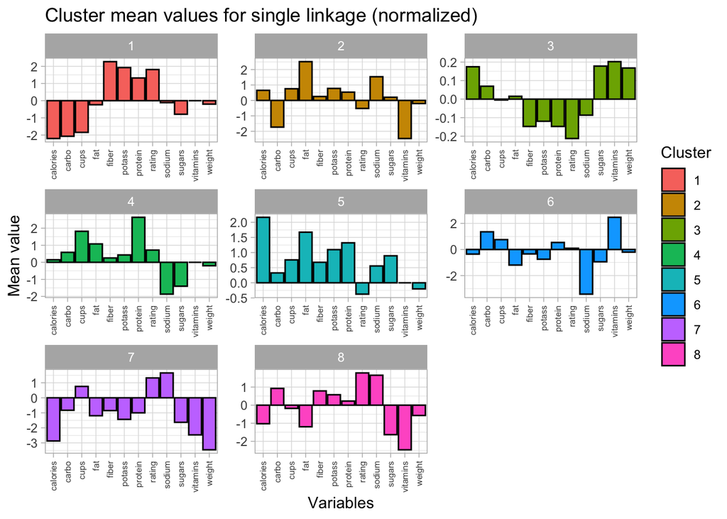

```r
# here x is the variables and we facet-wrap by cluster. we use normalized data
ggplot(CentSingleNorm, aes(x=Group.1, y=value, fill = as.factor(Cluster))) +
  geom_bar(stat = "identity", color = "black") +
  facet_wrap(~ as.factor(Cluster), scales = "free") +
  theme_light() +
  labs(x = "Variables", y = "Mean value", fill = "Cluster",
       title = "Cluster mean values for single linkage (normalized)") +
  # x axis labels vertical and tiny
  theme(axis.text.x = element_text(angle = 90, vjust = 0.5, hjust=1, size = 6))
```

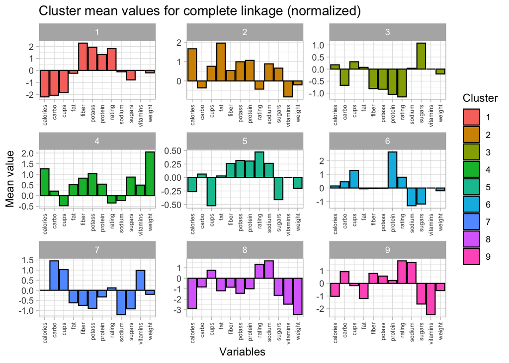

```r
ggplot(CentCompleteNorm, aes(x=Group.1, y=value, fill = as.factor(Cluster))) +
  geom_bar(stat='identity', color = "black") +
  facet_wrap(~ as.factor(Cluster), scales = "free") +
  theme_light() +
  labs(x = "Variables", y = "Mean value", fill = "Cluster",
       title = "Cluster mean values for complete linkage (normalized)") +
  theme(axis.text.x = element_text(angle = 90, vjust = 0.5, hjust=1, size = 6))
```

We can observe the differences or similarities between clusters in terms of shapes. For example cluster 4 and 8 in complete linkage seem to follow diametrically opposite patterns!

We now plot the cluster means by variable.

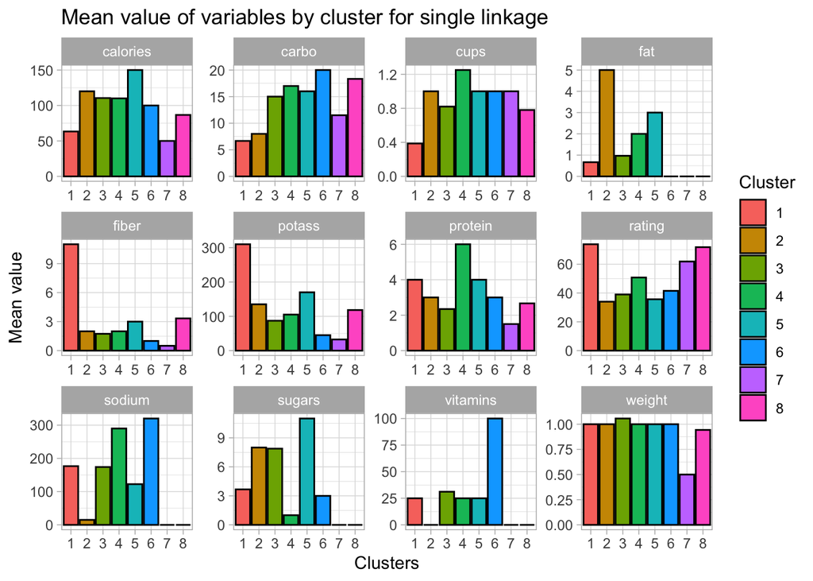

```r
# here x is the clusters and we facet-wrap by variable. we use data in its original scale.
ggplot(CentSingle, aes(x=as.factor(Cluster), y=value, fill = as.factor(Cluster))) +
  geom_bar(stat='identity', color = "black") +
  facet_wrap(~ Group.1, scales = "free") +
  theme_light() +
  labs(x = "Clusters", y = "Mean value", fill = "Cluster",
       title = "Mean value of variables by cluster for single linkage")
```

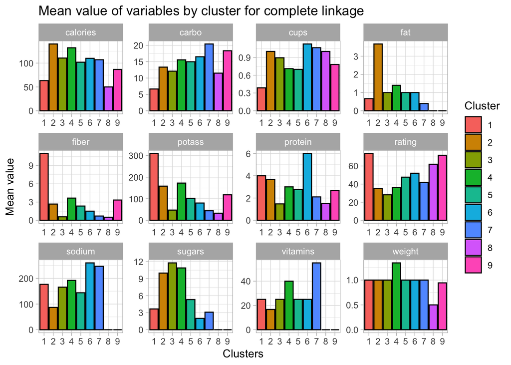

```r
ggplot(CentComplete, aes(x=as.factor(Cluster), y=value, fill = as.factor(Cluster))) +
  geom_bar(stat='identity', color = "black") +
  facet_wrap(~ Group.1, scales = "free") +
  theme_light() +
  labs(x = "Clusters", y = "Mean value", fill = "Cluster",
       title = "Mean value of variables by cluster for complete linkage")
```

Here, we can easily observe the difference for one variable between all clusters. For example, cluster 2 in complete linkage has a much higher concentration of fat, or clusters 7 and 8 in single linkage have no sugars. It is more convenient here to examine the variables in their original scale.

In general, single linkage gives clusters with a “sausage shaped” structure because of the use of the minimum. The clusters are more elongated. Here, it is difficult to visualize this effect directly, as we have a 12 dimensional space. Complete linkage gives more spherical clusters instead.

As for stability, our set is too small to be partitioned in a training and validation set and still have meaningful results. Moreover, hierarchical clustering tends to be unstable, so my assumption is that with such a small set, a few changes or perturbations in the data could lead to different clusters.

# 2 Which method leads to the most insightful or meaningful clusters?

Single linkage is designed to be used in situations where having elongated clusters would make sense. I do not think it is the case here. Moreover, we can see that the way single linkage builds the dendrogram leads to a set of clusters with few records and one cluster with the vast majority of records because of the decreasing cascade from left to right.

Thus, single linkage doesn’t seem very appropriate to group our records into different clusters.

# 3 Choose one of the methods. How many clusters would you use? What distance is used for this cutoff?

We choose complete linkage because of what we mentioned about single linkage above.

We have already chosen the number of clusters, 9, which was necessary to compute cluster centroids.

The distance used for the cutoff can be found inside our `Heights` data table. It is equal to 4.940472 as shown below.

```r
# 9 clusters --> 8 splits, there are 73 splits in total so height for 9 splits is at row 73-8=65
Heights[65,3]
```

```
##    CompleteHeight
## 1:       4.940472
```

# 4 The elementary public schools would like to choose a set of cereals to include in their daily cafeterias. Should the data be normalized? If not, how should they be used in the cluster analysis?

The data should be normalized to cluster. However, once the clustering process is finished, it is better to assign the clusters on the original, not transformed data. As we saw previously when plotting by variable, the plots give much more insight when variables are in their original scale. For example, a person with subject matter knowledge could look at the plot and decide to use a cluster which has a certain value of potassium, vitamins, etc. In order to do that, it is essential that the values are scaled back!

In short, we should normalize to cluster properly and present results in their original scale, as we did with predictive analysis (e.g. when examining retail prices of secondhand cars).